# MA615slides

12/02/2019

## Airbnb property price and related factors

## Background

Airbnb is a convenient website that we use to book lodging or primarily homestays. All of real estate listings are posted by property owners and these owners set unit room prices according to location, condition and many other seasonal influence factors. I plan to study elements that affect Airbnb room prices and try to find a model that could predict or provide a suggested price for Airbnb property. Then the model can be used by Airbnb hosts as a basic pricing tool.

## Research question

Which factors could affect Airbnb room prices?

## Data collection

I collect airbnb data of Boston in 2017. The dataset contains variables: room id, host id, room type, neighborhood, the number of reviews, the average rating, the number of guests a listing can accommodate, the number of bedrooms, the price for a night stay, latitude, longitude, the date and time that the values were read.

## Read Data

Airbnb has 7 sheets of 2017 Boston dataset available online, and I just donwload and read them in RStudio first.

## Data Cleaning

After viewing variables of each sheets, I find 4 sheets have 14 variables, while other 3 sheets have 20 variables. So, I decide to keep 14 variables.

## Data Organization

While combining these sheets, I find some properties have been updated and the whole sheet contains several obervations with same room_id. So, I delete duplicates and only keep the most recent observation. After data analysis, I also delete 2 blank columns and rows containing missing values. Next, I generate a new csv file containing all data.

## Text mining

```
## [1] "Reviews"
```

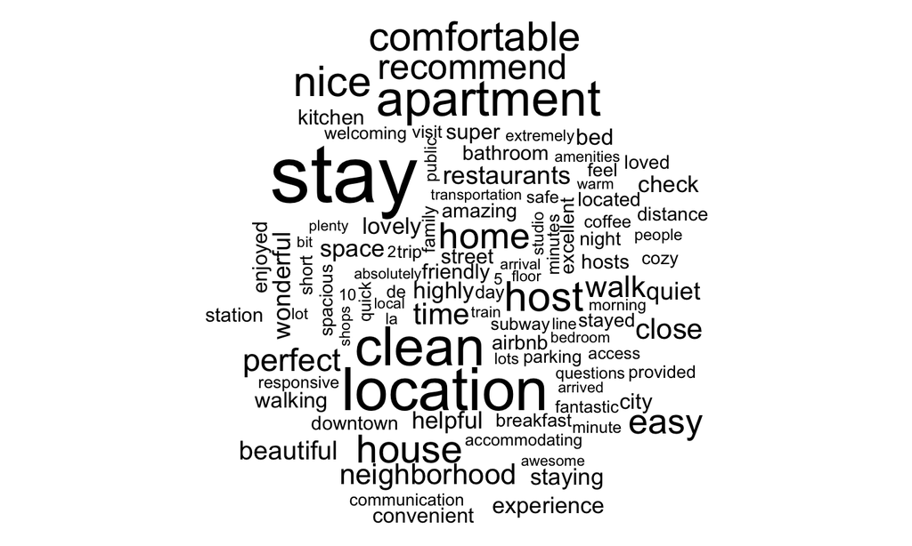

## EDA

## Data plots

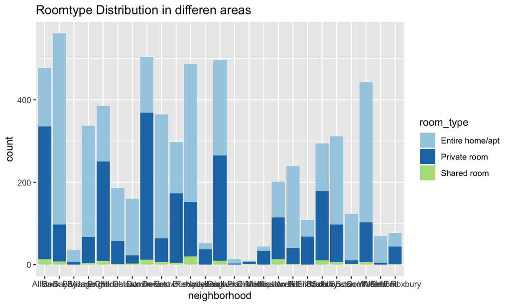

## Data plots

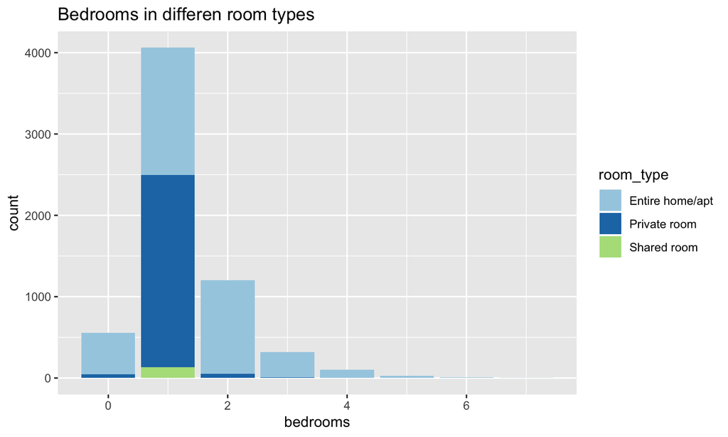

## Data plots

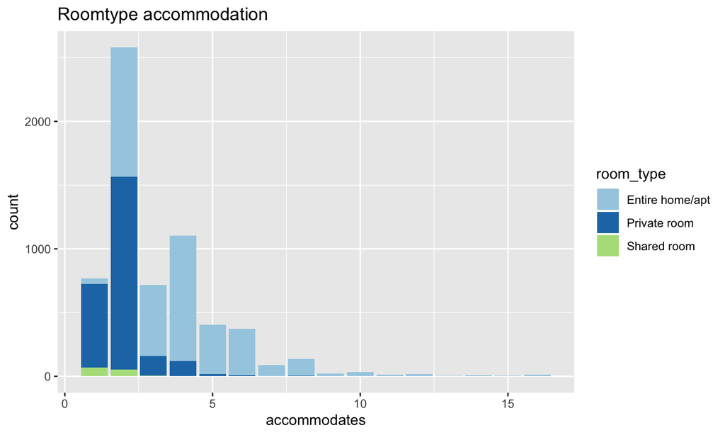

## Data plots

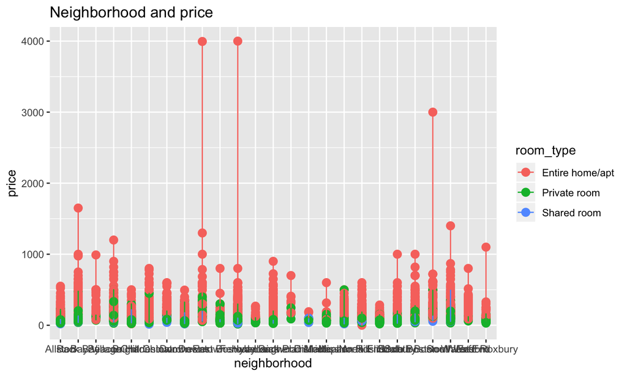

## Data plots

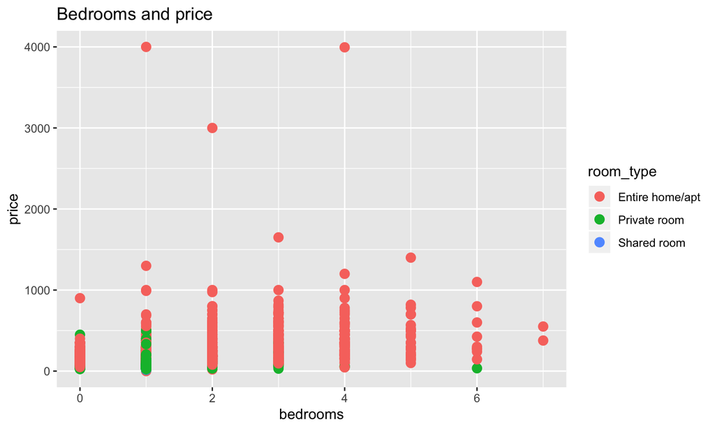

## Data plots

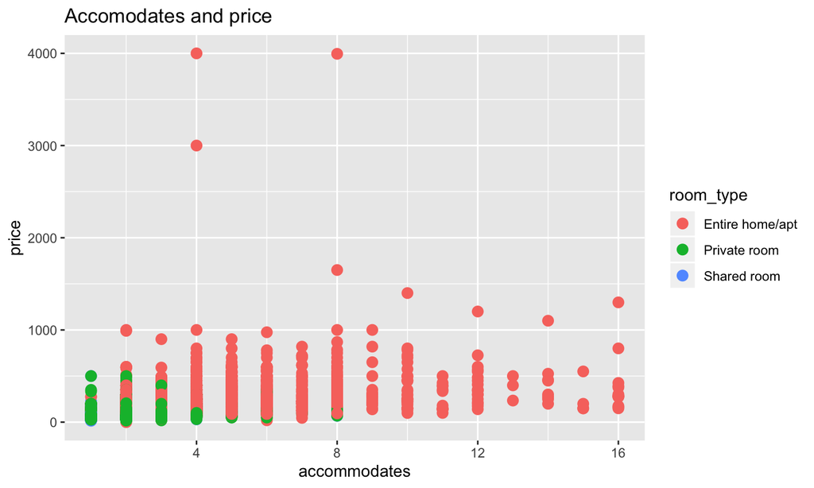

## Summary table

Location and price by average rating

| Location | Average Rating | Price |
| --- | --- | --- |
| Allston | 2.53 | 89.40 |
| Back Bay | 3.13 | 218.80 |
| Bay Village | 3.67 | 270.31 |
| Beacon Hill | 3.02 | 194.54 |
| Brighton | 2.74 | 93.73 |
| Charlestown | 3.53 | 201.94 |
| Chinatown | 4.10 | 232.96 |
| Dorchester | 2.87 | 91.88 |
| Downtown | 3.67 | 230.74 |
| East Boston | 3.02 | 111.36 |
| Fenway | 2.93 | 184.14 |
| Hyde Park | 2.75 | 81.75 |
| Jamaica Plain | 3.21 | 132.41 |
| Leather District | 3.38 | 278.77 |
| Longwood Medical Area | 2.20 | 98.70 |
| Mattapan | 3.00 | 98.36 |
| Mission Hill | 2.73 | 124.71 |
| North End | 3.58 | 172.13 |
| Roslindale | 3.13 | 87.96 |
| Roxbury | 3.22 | 119.08 |
| South Boston | 3.99 | 188.60 |
| South Boston Waterfront | 3.81 | 306.25 |
| South End | 2.93 | 192.68 |
| West End | 3.68 | 241.94 |
| West Roxbury | 3.23 | 114.34 |

## Concerns

Zero values in “the number of reviews” and “the average rating” may lead to potential problems. Usually, living spots with unattractive appearance or location probably have few or no reviews. But new posted houses also have zero review since no one has stayed before. If I keep these zero values in the fitted model, the model will predict relatively low prices for those new lodgings. In addition, the plot shows 3 outliers with pretty high price above $3000, which might make regression less reliable. In this way, I remove these observations.

## Methods

## Correlation

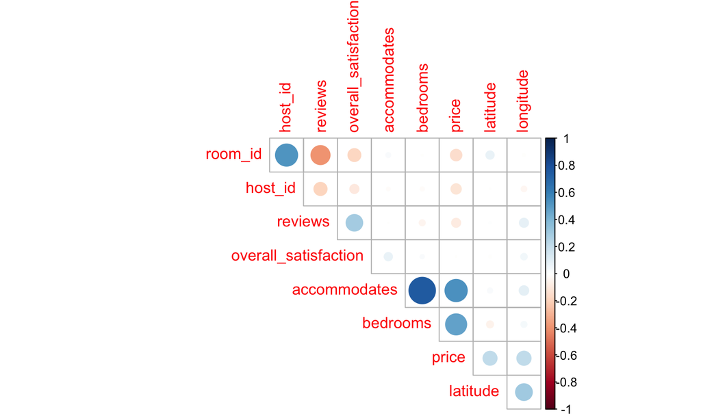

## EFA

Dataset has 12 variables and I want to find out the number of factors that will be selected for later analysis.

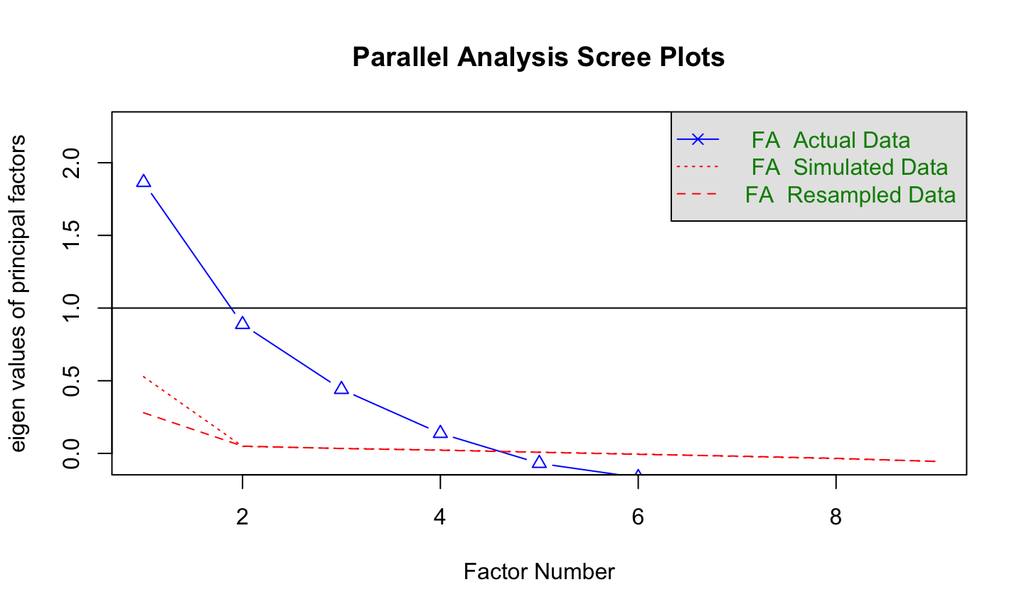

```
## Parallel analysis suggests that the number of factors =  4  and the number of components =  NA
```

## EFA

The blue line shows eigenvalues of actual data and the two red lines (placed on top of each other) show simulated and resampled data. Here we look at the large drops in the actual data and spot the point where it levels off to the right. Also we locate the point of inflection – the point where the gap between simulated data and actual data tends to be minimum.

## EFA

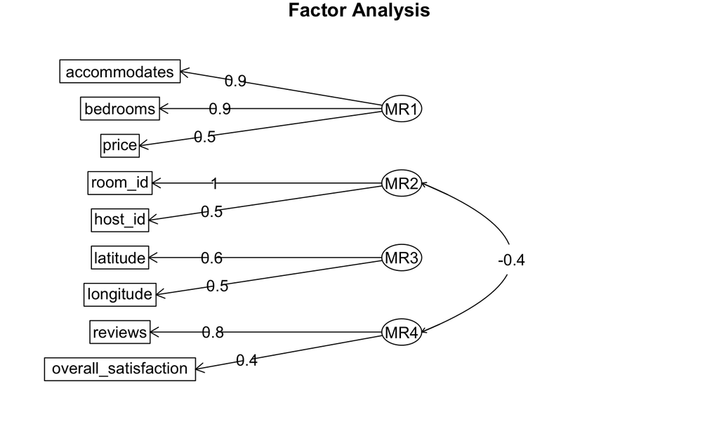

## Random Forest

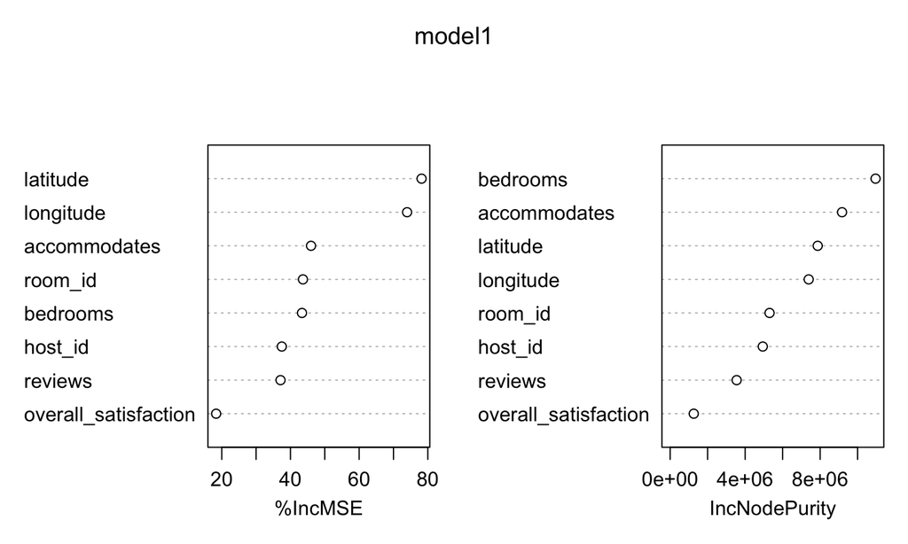

## Model

```
## lm(formula = price ~ log(accommodates) + bedrooms + reviews *
##     overall_satisfaction + as.factor(neighborhood) + as.factor(room_type),
##     data = mydata)
##                                                coef.est coef.se
## (Intercept)                                     66.72     5.53
## log(accommodates)                               21.85     3.08
## bedrooms                                        46.83     1.80
## reviews                                         -1.07     0.32
## overall_satisfaction                            -1.51     0.60
## as.factor(neighborhood)Back Bay                 82.71     5.43
## as.factor(neighborhood)Bay Village              86.37    13.41
## as.factor(neighborhood)Beacon Hill              71.29     6.01
## as.factor(neighborhood)Brighton                 -7.41     5.86
## as.factor(neighborhood)Charlestown              50.47     7.38
## as.factor(neighborhood)Chinatown                65.34     8.44
## as.factor(neighborhood)Dorchester               -8.04     5.30
## as.factor(neighborhood)Downtown                 67.04     6.14
## as.factor(neighborhood)East Boston               0.82     6.06
## as.factor(neighborhood)Fenway                   57.15     5.64
## as.factor(neighborhood)Hyde Park               -20.16    12.53
## as.factor(neighborhood)Jamaica Plain            10.30     5.36
## as.factor(neighborhood)Leather District        138.45    22.18
## as.factor(neighborhood)Longwood Medical Area    45.86    29.95
## as.factor(neighborhood)Mattapan                -10.13    12.52
## as.factor(neighborhood)Mission Hill             13.92     7.73
## as.factor(neighborhood)North End                30.54     6.57
## as.factor(neighborhood)Roslindale              -21.91     8.53
## as.factor(neighborhood)Roxbury                   9.00     6.15
## as.factor(neighborhood)South Boston             41.62     6.08
## as.factor(neighborhood)South Boston Waterfront 122.91     8.84
## as.factor(neighborhood)South End                73.92     5.56
## as.factor(neighborhood)West End                 62.27    12.74
## as.factor(neighborhood)West Roxbury            -18.35    10.35
## as.factor(room_type)Private room               -56.02     2.99
## as.factor(room_type)Shared room                -86.59     8.34
## reviews:overall_satisfaction                     0.21     0.07
## ---
## n = 4765, k = 32
## residual sd = 72.31, R-Squared = 0.54
```

## Check Model

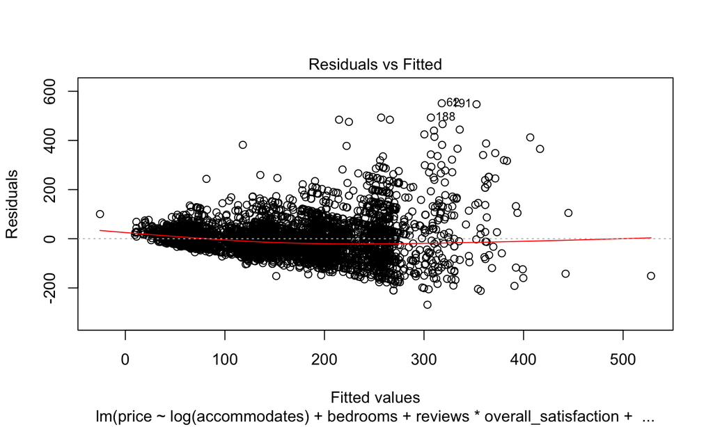

## Check Model

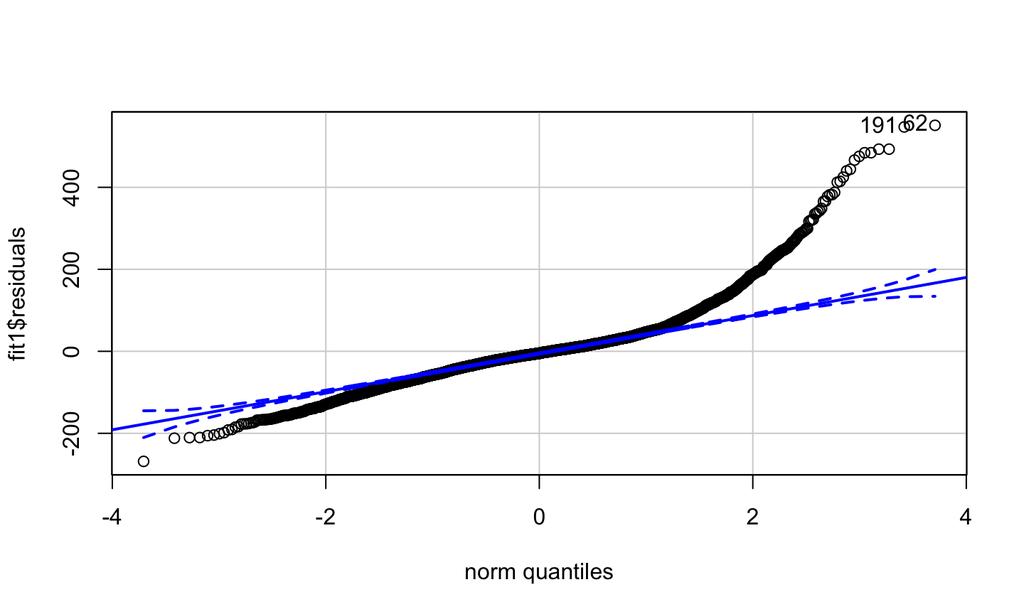

```
## [1]  62 191
```

## Citation

http://tomslee.net/airbnb-data-collection-get-the-data

http://insideairbnb.com/get-the-data.html